# Business Statistics Assessment IB94X0 2024-2025 #2

## 4.7 Comparison of Models

```r
lm_Staff_Delivery <- lm(customer.satisfaction ~ staff.satisfaction + delivery.time, data = raw_cs.data)
summary(lm_Staff_Delivery)
```

```
##
## Call:
## lm(formula = customer.satisfaction ~ staff.satisfaction + delivery.time,
##     data = raw_cs.data)
##
## Residuals:
##     Min      1Q  Median      3Q     Max
## -3.2532 -0.7662  0.0534  0.7489  3.2985
##
## Coefficients:
##                     Estimate Std. Error t value Pr(>|t|)
## (Intercept)         3.570086   0.669333   5.334 1.91e-07 ***
## staff.satisfaction  0.724300   0.082111   8.821  < 2e-16 ***
## delivery.time      -0.025675   0.005602  -4.583 6.76e-06 ***
## ---
## Signif. codes:  0 '***' 0.001 '**' 0.01 '*' 0.05 '.' 0.1 ' ' 1
##
## Residual standard error: 1.117 on 297 degrees of freedom
## Multiple R-squared:  0.2608, Adjusted R-squared:  0.2558
## F-statistic: 52.39 on 2 and 297 DF,  p-value: < 2.2e-16
```

```r
#Since we got a common trend of both staff satisfaction and delivery time being significant, we create a model using these two factors and get common results. With a R square value of 0.25 explaining the variance in the data we get a decent model. These findings are statistically significant and provide a strong indication that improving staff satisfaction and reducing delivery time could enhance customer satisfaction.
```

```r
anova_results <- anova(lm_Staff_Delivery, lm_all_factors_raw_cs_data)


print(anova_results)
```

```
## Analysis of Variance Table
##
## Model 1: customer.satisfaction ~ staff.satisfaction + delivery.time
## Model 2: customer.satisfaction ~ staff.satisfaction + delivery.time +
##     new_range + SES_category
##   Res.Df    RSS Df Sum of Sq      F    Pr(>F)
## 1    297 370.29
## 2    294 276.94  3    93.351 33.034 < 2.2e-16 ***
## ---
## Signif. codes:  0 '***' 0.001 '**' 0.01 '*' 0.05 '.' 0.1 ' ' 1
```

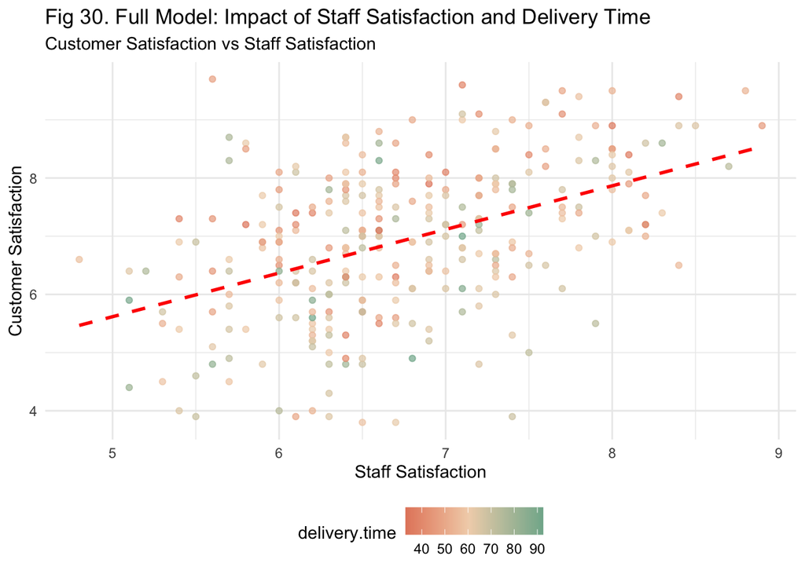

```r
raw_cs.data$predicted_all_factors <- predict(lm_all_factors_raw_cs_data, raw_cs.data)


plot_all_factors <- ggplot(raw_cs.data, aes(x = staff.satisfaction, y = customer.satisfaction, colour = delivery.time)) +
  geom_point(alpha = 0.7) +
  geom_smooth(method = "lm", aes(x = staff.satisfaction, y = predicted_all_factors), colour = "red", linetype = "dashed", se = FALSE) +
  scale_colour_gradient2(low = "#E07A5F", mid = "#F1D4B8", high = "#81B29A", midpoint = median(raw_cs.data$delivery.time)) +
  theme_minimal() +
  labs(title = "Fig 30. Full Model: Impact of Staff Satisfaction and Delivery Time",
       subtitle = "Customer Satisfaction vs Staff Satisfaction",
       x = "Staff Satisfaction",
       y = "Customer Satisfaction") +
  theme(legend.position = "bottom")


grid.arrange(plot_all_factors,ncol = 1)
```

```r
#Based on the visual, we can confirm the model fits the data well. However, at lower and higher levels there seems to be some variance.
```

```r
vif_values_cs <- vif(lm_all_factors_raw_cs_data)


print(vif_values_cs)
```

```
##                        GVIF Df GVIF^(1/(2*Df))
## staff.satisfaction 1.273857  1        1.128653
## delivery.time      1.041799  1        1.020685
## new_range          1.004067  1        1.002031
## SES_category       1.317645  2        1.071395
```

```r
confint(lm_all_factors_raw_cs_data)
```

```
##                          2.5 %       97.5 %
## (Intercept)         3.97392752  6.379890870
## staff.satisfaction  0.19895230  0.515295832
## delivery.time      -0.02701286 -0.007494506
## new_rangeTRUE      -0.12581520  0.316829155
## SES_categoryLow    -0.52239539  0.024096535
## SES_categoryMedium  0.91788234  1.500178007
```

When confirmed with Variance Inflation Factor (VIF), the values are less hence suggesting we can ingore the issue of multicollinearity.

1. Staff Satisfaction: When other factors are controlled, the Staff Satisfaction factor affects customer satisfaction between 0.19 and 0.51 values indicating a significant positive relation.
2. Delivery Time: When other factors are controlled, the Delivery Time factor affects customer satisfaction between -0.02 and -0.007 values indicating a significant negative relation.
3. New Range (True): When other factors are controlled, the range when true factor affects customer satisfaction between -0.12 and 0.31 values indicating an insignificant relation since 0 comes between the interval.
4. SES_category (Low): When other factors are controlled, the SES_category when low factor affects customer satisfaction between -0.52 and 0.02 values indicating an insignificant relation since 0 comes between the interval.
5. SES_category (Medium): When other factors are controlled, the SES_category when medium factor affects customer satisfaction between 0.91 and 1.50 values indicating a significant positive relation.

# 5 Question 2 - Effect of delivery times upon customer satisfaction across Socio-Economic-Status

```r
# Since we have already carried out steps of Data Loading, Data Understanding, Data Transformations, we will directly skip to the modelling of delivery times upon customer satisfaction across Socio-Economic-Status.

# Linear model considering the interaction between SES category and delivery time on customer satisfaction
lm_DeliveryTime_SESInteraction <- lm(customer.satisfaction ~ delivery.time * SES_category, data = raw_cs.data)
summary(lm_DeliveryTime_SESInteraction)
```

```
##
## Call:
## lm(formula = customer.satisfaction ~ delivery.time * SES_category,
##     data = raw_cs.data)
##
## Residuals:
##      Min       1Q   Median       3Q      Max
## -2.41335 -0.63495  0.01495  0.72612  2.57692
##
## Coefficients:
##                                   Estimate Std. Error t value Pr(>|t|)
## (Intercept)                       8.649399   0.573708  15.076  < 2e-16 ***
## delivery.time                    -0.035222   0.009489  -3.712 0.000246 ***
## SES_categoryLow                  -2.151516   0.776862  -2.769 0.005971 **
## SES_categoryMedium                0.261755   0.766140   0.342 0.732855
## delivery.time:SES_categoryLow     0.030316   0.012572   2.411 0.016508 *
## delivery.time:SES_categoryMedium  0.020013   0.012909   1.550 0.122146
## ---
## Signif. codes:  0 '***' 0.001 '**' 0.01 '*' 0.05 '.' 0.1 ' ' 1
##
## Residual standard error: 0.9943 on 294 degrees of freedom
## Multiple R-squared:  0.4197, Adjusted R-squared:  0.4099
## F-statistic: 42.53 on 5 and 294 DF,  p-value: < 2.2e-16
```

```r
#The model predicts that for 1 unit increase in delivery time, the customer satisfaction decreases by 0.035 units. With a very small value of P, we can confirm this relation is statistically significant.

#The model predicts that for customers in Low SES_category, the customer satisfaction decreases by 2.15 units. With a small value of P, we can confirm this relation is statistically significant. However, for customers in Medium SES_category, the customer satisfaction increases by 0.26 units however the relation is not significant.

#The model predicts that when the interaction term of delivery time and SES_category of Low, the customer satisfaction increases by 0.03 units with a statistically significant relation. On the other hand, model predicts that when the interaction term of delivery time and SES_category of Medium, the customer satisfaction increases by 0.02 units with a statistically insignificant relation.
#With a very good R square value of 0.40, it suggests the model is not over fit and explains the variance in the data well.

#With significant relations for delivery time, it still remains a very important factor for customer satisfaction.
#The high value of SES_categoryLow suggests greater dissatisfaction among these customers in general as compared to other groups.
#The comparatively higher value for delivery.time:SES_categoryLow, suggests that people of this low category are still okay with delivery being late as compared to the Medium category.
```

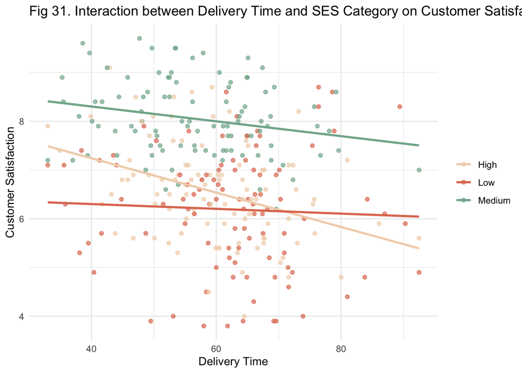

```r
ggplot(raw_cs.data, aes(x = delivery.time, y = customer.satisfaction, colour = SES_category)) +
  geom_point(alpha = 0.7) +
  geom_smooth(method = "lm", aes(colour = SES_category), se = FALSE) +
  scale_colour_manual(values = c("Low" = "#E07A5F", "Medium" = "#81B29A", "High" = "#F1D4B8")) +
  theme_minimal() +
  labs(title = "Fig 31. Interaction between Delivery Time and SES Category on Customer Satisfaction",
       x = "Delivery Time",
       y = "Customer Satisfaction") +
  theme(legend.title = element_blank())
```

At lower levels of delivery time, Medium Category are satisfied the most, followed by High Category and then Low Category.

```r
vif_values_cs_ <- vif(lm_DeliveryTime_SESInteraction)


print(vif_values_cs_)
```

```
##                                  GVIF Df GVIF^(1/(2*Df))
## delivery.time                3.634473  1        1.906429
## SES_category               838.680055  2        5.381447
## delivery.time:SES_category 906.825697  2        5.487581
```

```r
confint(lm_DeliveryTime_SESInteraction)
```

```
##                                         2.5 %      97.5 %
## (Intercept)                       7.520303498  9.77849434
## delivery.time                    -0.053896152 -0.01654782
## SES_categoryLow                  -3.680431905 -0.62260009
## SES_categoryMedium               -1.246058566  1.76956768
## delivery.time:SES_categoryLow     0.005572787  0.05505954
## delivery.time:SES_categoryMedium -0.005393137  0.04542002
```

The Variance Inflation Factors (VIF) score for delivery time is less and acceptable. However very high for SES_category, although this generally happens for categorical variables.

1. Delivery Time: When other factors are controlled, the Delivery Time factor affects customer satisfaction between -0.05 and -0.01 values indicating a significant negative relation.
2. SES_category (Low): When other factors are controlled, the SES_category when low factor affects customer satisfaction between -3.68 and -0.62 values indicating a significant relation.
3. SES_category (Medium): When other factors are controlled, the SES_category when medium factor affects customer satisfaction between -1.24 and 1.76 values indicating an insignificant relation.
4. Delivery Time:SES_category (Low): When other factors are controlled, the Delivery Time:SES_category (Low) factor affects the customer satisfaction between 0.005 and 0.055 indicating a significant positive relation.
5. Delivery Time:SES_category (Medium): When other factors are controlled, the Delivery Time:SES_category (Medium) factor affects the customer satisfaction between -0.005 and 0.04 indicating an insignificant relation.

# 6 References

1. Newman, D.A., 2014. Missing data: Five practical guidelines. Organizational Research Methods, 17(4), pp.372-411. ScienceDirect, 2023. Missing data considerations in statistical analysis. Available at: https://www.sciencedirect.com/science/article/pii/S1326020023036488 [Accessed 19 January 2025].
2. Kaur, P., Stoltzfus, J. and Yellapu, V., 2018. Descriptive statistics. International Journal of Academic Medicine, 4(1), pp.60-63. Available at: https://doi.org/10.4103/IJAM.IJAM_7_18 [Accessed 19 January 2025].